# Coursera_machine_learning_assignment

## 5. Correlation analysis

As a part of initial analysis process, we need to draw few plots to check the relation between variables from the training dataset

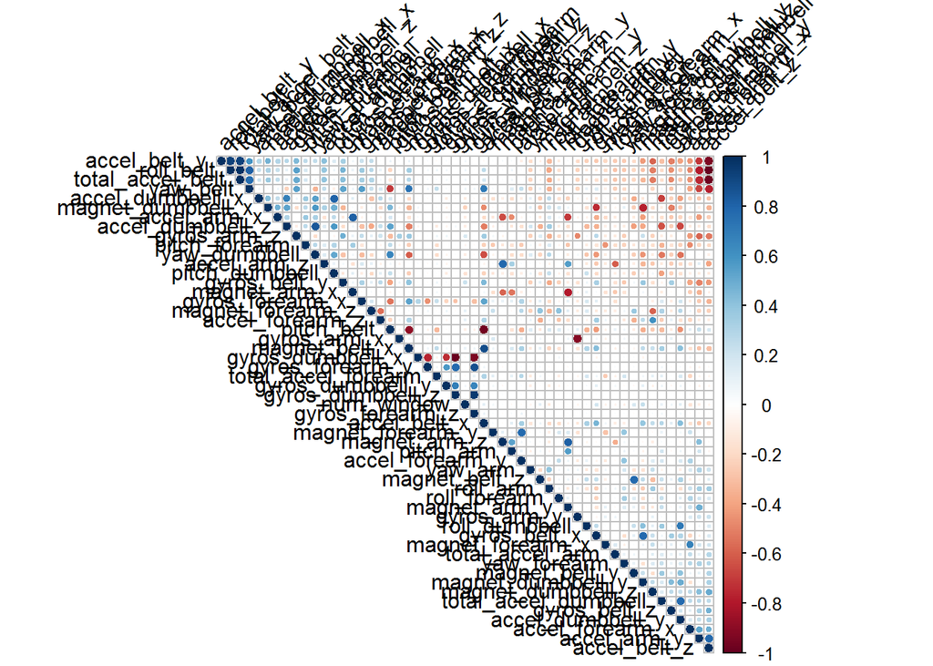

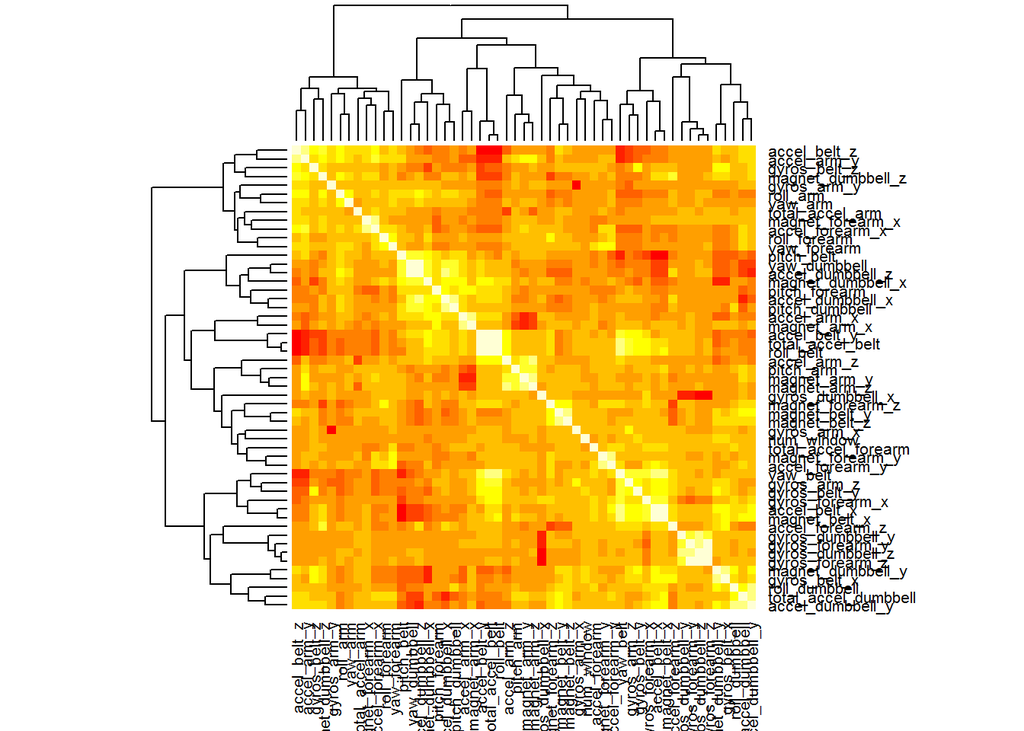

After plotting the variables using correlated plots and heatmap , we could see that the related variables,which are shown on dark colors, are very few in numbers so there is no need to perform PCA(Principal component analysis) test further.

## 6. Predictive model building

In this particular exercise , there are three popular methods will be used to build a regression model for the train dataset and the best model with the highest accuracy will be applied to test dataset for quiz predictions. Three regression model methods are defined below: a) Random Forest b) Decision Tree c) Generalized Boosted Model

In order to measure the performance level a confusionmatrix will be drawn to find the best fitted model with highest accuracy.

### Random Forest Model

```r
#train the model using random forest method
controlRF <- trainControl(method = "cv",number=3, verboseIter=FALSE)
modrandomforest <- train(classe ~ .,data=Trainset,method="rf",trControl=controlRF)
modrandomforest
```

```
## Random Forest
##
## 13737 samples
##    53 predictor
##     5 classes: 'A', 'B', 'C', 'D', 'E'
##
## No pre-processing
## Resampling: Cross-Validated (3 fold)
## Summary of sample sizes: 9158, 9157, 9159
## Resampling results across tuning parameters:
##
##   mtry  Accuracy   Kappa
##    2    0.9914097  0.9891326
##   27    0.9959233  0.9948431
##   53    0.9936665  0.9919882
##
## Accuracy was used to select the optimal model using the largest value.
## The final value used for the model was mtry = 27.
```

```r
#prediction on test dataset
predictrf <- predict(modrandomforest,newdata = Testset)
#Find accuracy using confusion matrix
confrandomforest <- confusionMatrix(predictrf,Testset$classe)
confrandomforest
```

```
## Confusion Matrix and Statistics
##
##           Reference
## Prediction    A    B    C    D    E
##          A 1674    5    0    0    0
##          B    0 1133    2    0    0
##          C    0    1 1024    3    0
##          D    0    0    0  961    3
##          E    0    0    0    0 1079
##
## Overall Statistics
##
##                Accuracy : 0.9976
##                  95% CI : (0.996, 0.9987)
##     No Information Rate : 0.2845
##     P-Value [Acc > NIR] : < 2.2e-16
##
##                   Kappa : 0.997
##  Mcnemar's Test P-Value : NA
##
## Statistics by Class:
##
##                      Class: A Class: B Class: C Class: D Class: E
## Sensitivity            1.0000   0.9947   0.9981   0.9969   0.9972
## Specificity            0.9988   0.9996   0.9992   0.9994   1.0000
## Pos Pred Value         0.9970   0.9982   0.9961   0.9969   1.0000
## Neg Pred Value         1.0000   0.9987   0.9996   0.9994   0.9994
## Prevalence             0.2845   0.1935   0.1743   0.1638   0.1839
## Detection Rate         0.2845   0.1925   0.1740   0.1633   0.1833
## Detection Prevalence   0.2853   0.1929   0.1747   0.1638   0.1833
## Balanced Accuracy      0.9994   0.9972   0.9986   0.9981   0.9986
```

```r
confrandomforest$overall['Accuracy']
```

```
##  Accuracy
## 0.9976211
```

### Decision Tree Model

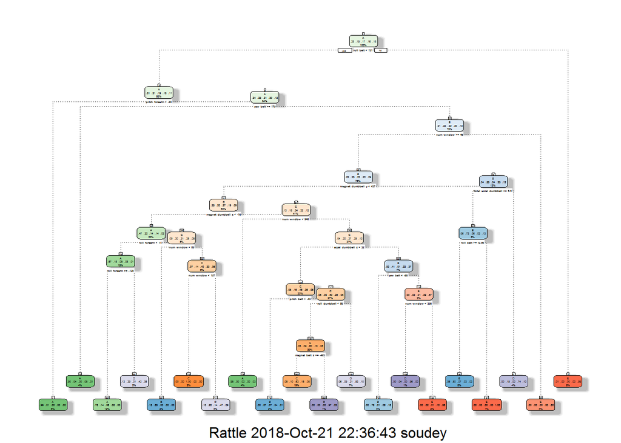

```r
moddecisiontree <- rpart(classe ~ .,data=Trainset,method="class")
fancyRpartPlot(moddecisiontree)
```

```r
#prediction on test dataset
predictdc <- predict(moddecisiontree,newdata = Testset,type = "class")
#Find accuracy using confusion matrix
confdc <- confusionMatrix(predictdc,Testset$classe)
confdc
```

```
## Confusion Matrix and Statistics
##
##           Reference
## Prediction    A    B    C    D    E
##          A 1499  117   55   26   16
##          B   38  709   51   24   50
##          C   59  106  797  177   95
##          D   75  200  122  675  100
##          E    3    7    1   62  821
##
## Overall Statistics
##
##                Accuracy : 0.7648
##                  95% CI : (0.7538, 0.7756)
##     No Information Rate : 0.2845
##     P-Value [Acc > NIR] : < 2.2e-16
##
##                   Kappa : 0.7028
##  Mcnemar's Test P-Value : < 2.2e-16
##
## Statistics by Class:
##
##                      Class: A Class: B Class: C Class: D Class: E
## Sensitivity            0.8955   0.6225   0.7768   0.7002   0.7588
## Specificity            0.9492   0.9657   0.9101   0.8990   0.9848
## Pos Pred Value         0.8751   0.8131   0.6459   0.5759   0.9183
## Neg Pred Value         0.9581   0.9142   0.9508   0.9387   0.9477
## Prevalence             0.2845   0.1935   0.1743   0.1638   0.1839
## Detection Rate         0.2547   0.1205   0.1354   0.1147   0.1395
## Detection Prevalence   0.2911   0.1482   0.2097   0.1992   0.1519
## Balanced Accuracy      0.9223   0.7941   0.8434   0.7996   0.8718
```

```r
confdc$overall['Accuracy']
```

```
##  Accuracy
## 0.7648258
```

### Generalized Boosted Model(GBM)

```r
controlGBM <- trainControl(method = "repeatedcv",number=3, verboseIter=FALSE)
modgbm <- train(classe ~ .,data=Trainset,method="gbm",trControl=controlGBM)
#prediction on test dataset
predictgbm <- predict(modgbm,newdata = Testset)
#Find accuracy using confusion matrix
confgbm <- confusionMatrix(predictgbm,Testset$classe)
confgbm
```

```
## Confusion Matrix and Statistics
##
##           Reference
## Prediction    A    B    C    D    E
##          A 1673   15    0    1    0
##          B    1 1120   13    5    4
##          C    0    4 1008   16    5
##          D    0    0    4  942   11
##          E    0    0    1    0 1062
##
## Overall Statistics
##
##                Accuracy : 0.9864
##                  95% CI : (0.9831, 0.9892)
##     No Information Rate : 0.2845
##     P-Value [Acc > NIR] : < 2.2e-16
##
##                   Kappa : 0.9828
##  Mcnemar's Test P-Value : NA
##
## Statistics by Class:
##
##                      Class: A Class: B Class: C Class: D Class: E
## Sensitivity            0.9994   0.9833   0.9825   0.9772   0.9815
## Specificity            0.9962   0.9952   0.9949   0.9970   0.9998
## Pos Pred Value         0.9905   0.9799   0.9758   0.9843   0.9991
## Neg Pred Value         0.9998   0.9960   0.9963   0.9955   0.9959
## Prevalence             0.2845   0.1935   0.1743   0.1638   0.1839
## Detection Rate         0.2843   0.1903   0.1713   0.1601   0.1805
## Detection Prevalence   0.2870   0.1942   0.1755   0.1626   0.1806
## Balanced Accuracy      0.9978   0.9892   0.9887   0.9871   0.9907
```

```r
confgbm$overall['Accuracy']
```

```
##  Accuracy
## 0.9864061
```

## 7. Apply the best accurate model to test data

Based on the confusionmatrix analysis results, the random forest method prouced the best accurate prediction on the “classe” variable of the test dataset. The Random Forest model will be applied to the original test dataset for final predictions.

```r
finalpredict <- predict(modrandomforest,newdata = test_pml)
finalpredict
```

```
##  [1] B A B A A E D B A A B C B A E E A B B B
## Levels: A B C D E
```